# Arithmetic & Logical Operators, R Data Types

# Inputs & Outputs

## Read CSV

Comes with the internal library `utils`

`read.csv(file, header = TRUE, sep = ",")`

Argument:

`file`: PATH where the file is stored  
`header`: confirm if the file has a header or not, by default, the header is set to `TRUE`  
`sep`: the symbol used to split the variable. By default, `,`.  
For windows user:  
`"C:\Users\USERNAME\Downloads\FILENAME.csv"`

```r
PATH <- 'https://raw.githubusercontent.com/guru99-edu/R-Programming/master/mtcars.csv'
df <- read.csv(PATH, header =  TRUE, sep = ',')
df
```

| X | mpg | cyl | disp | hp | drat | wt | qsec | vs | am | gear | carb |
| --- | --- | --- | --- | --- | --- | --- | --- | --- | --- | --- | --- |
| Mazda RX4 | 21.0 | 6 | 160.0 | 110 | 3.90 | 2.620 | 16.46 | 0 | 1 | 4 | 4 |
| Mazda RX4 Wag | 21.0 | 6 | 160.0 | 110 | 3.90 | 2.875 | 17.02 | 0 | 1 | 4 | 4 |
| Datsun 710 | 22.8 | 4 | 108.0 | 93 | 3.85 | 2.320 | 18.61 | 1 | 1 | 4 | 1 |
| Hornet 4 Drive | 21.4 | 6 | 258.0 | 110 | 3.08 | 3.215 | 19.44 | 1 | 0 | 3 | 1 |
| Hornet Sportabout | 18.7 | 8 | 360.0 | 175 | 3.15 | 3.440 | 17.02 | 0 | 0 | 3 | 2 |
| Valiant | 18.1 | 6 | 225.0 | 105 | 2.76 | 3.460 | 20.22 | 1 | 0 | 3 | 1 |
| Duster 360 | 14.3 | 8 | 360.0 | 245 | 3.21 | 3.570 | 15.84 | 0 | 0 | 3 | 4 |
| Merc 240D | 24.4 | 4 | 146.7 | 62 | 3.69 | 3.190 | 20.00 | 1 | 0 | 4 | 2 |
| Merc 230 | 22.8 | 4 | 140.8 | 95 | 3.92 | 3.150 | 22.90 | 1 | 0 | 4 | 2 |
| Merc 280 | 19.2 | 6 | 167.6 | 123 | 3.92 | 3.440 | 18.30 | 1 | 0 | 4 | 4 |
| Merc 280C | 17.8 | 6 | 167.6 | 123 | 3.92 | 3.440 | 18.90 | 1 | 0 | 4 | 4 |
| Merc 450SE | 16.4 | 8 | 275.8 | 180 | 3.07 | 4.070 | 17.40 | 0 | 0 | 3 | 3 |
| Merc 450SL | 17.3 | 8 | 275.8 | 180 | 3.07 | 3.730 | 17.60 | 0 | 0 | 3 | 3 |
| Merc 450SLC | 15.2 | 8 | 275.8 | 180 | 3.07 | 3.780 | 18.00 | 0 | 0 | 3 | 3 |
| Cadillac Fleetwood | 10.4 | 8 | 472.0 | 205 | 2.93 | 5.250 | 17.98 | 0 | 0 | 3 | 4 |
| Lincoln Continental | 10.4 | 8 | 460.0 | 215 | 3.00 | 5.424 | 17.82 | 0 | 0 | 3 | 4 |
| Chrysler Imperial | 14.7 | 8 | 440.0 | 230 | 3.23 | 5.345 | 17.42 | 0 | 0 | 3 | 4 |
| Fiat 128 | 32.4 | 4 | 78.7 | 66 | 4.08 | 2.200 | 19.47 | 1 | 1 | 4 | 1 |
| Honda Civic | 30.4 | 4 | 75.7 | 52 | 4.93 | 1.615 | 18.52 | 1 | 1 | 4 | 2 |
| Toyota Corolla | 33.9 | 4 | 71.1 | 65 | 4.22 | 1.835 | 19.90 | 1 | 1 | 4 | 1 |
| Toyota Corona | 21.5 | 4 | 120.1 | 97 | 3.70 | 2.465 | 20.01 | 1 | 0 | 3 | 1 |
| Dodge Challenger | 15.5 | 8 | 318.0 | 150 | 2.76 | 3.520 | 16.87 | 0 | 0 | 3 | 2 |
| AMC Javelin | 15.2 | 8 | 304.0 | 150 | 3.15 | 3.435 | 17.30 | 0 | 0 | 3 | 2 |
| Camaro Z28 | 13.3 | 8 | 350.0 | 245 | 3.73 | 3.840 | 15.41 | 0 | 0 | 3 | 4 |
| Pontiac Firebird | 19.2 | 8 | 400.0 | 175 | 3.08 | 3.845 | 17.05 | 0 | 0 | 3 | 2 |
| Fiat X1-9 | 27.3 | 4 | 79.0 | 66 | 4.08 | 1.935 | 18.90 | 1 | 1 | 4 | 1 |
| Porsche 914-2 | 26.0 | 4 | 120.3 | 91 | 4.43 | 2.140 | 16.70 | 0 | 1 | 5 | 2 |
| Lotus Europa | 30.4 | 4 | 95.1 | 113 | 3.77 | 1.513 | 16.90 | 1 | 1 | 5 | 2 |
| Ford Pantera L | 15.8 | 8 | 351.0 | 264 | 4.22 | 3.170 | 14.50 | 0 | 1 | 5 | 4 |
| Ferrari Dino | 19.7 | 6 | 145.0 | 175 | 3.62 | 2.770 | 15.50 | 0 | 1 | 5 | 6 |
| Maserati Bora | 15.0 | 8 | 301.0 | 335 | 3.54 | 3.570 | 14.60 | 0 | 1 | 5 | 8 |
| Volvo 142E | 21.4 | 4 | 121.0 | 109 | 4.11 | 2.780 | 18.60 | 1 | 1 | 4 | 2 |

```r
length(df)
```

12

```r
class(df$X)
```

'factor'

## Read Excel files

Needs `readxl` library

The function `read_excel()` is of great use when it comes to opening xls and xlsx extention.

The syntax is:  
`read_excel(PATH, sheet = NULL, range= NULL, col_names = TRUE)`  
arguments:  
`PATH`: Path where the excel is located  
`sheet`: Select the sheet to import. By default, all  
`range`: Select the range to import. By default, all non-null cells  
`col_names`: Select the columns to import. By default, all non-null columns

```r
# Install and activate library `readxl`
require(readxl)
library(readxl)
# We can import the spreadsheets from the readxl library and count the number of columns in the first sheet.
readxl_example()
```

1. 'clippy.xls'

2. 'clippy.xlsx'

3. 'datasets.xls'

4. 'datasets.xlsx'

5. 'deaths.xls'

6. 'deaths.xlsx'

7. 'geometry.xls'

8. 'geometry.xlsx'

9. 'type-me.xls'

10. 'type-me.xlsx'

```r
# Store the path of `datasets.xlsx`
example <- readxl_example("datasets.xlsx")
# Import the spreadsheet
df <- read_excel(example)
df
```

| Sepal.Length | Sepal.Width | Petal.Length | Petal.Width | Species |
| --- | --- | --- | --- | --- |
| 5.1 | 3.5 | 1.4 | 0.2 | setosa |
| 4.9 | 3.0 | 1.4 | 0.2 | setosa |
| 4.7 | 3.2 | 1.3 | 0.2 | setosa |
| 4.6 | 3.1 | 1.5 | 0.2 | setosa |
| 5.0 | 3.6 | 1.4 | 0.2 | setosa |
| 5.4 | 3.9 | 1.7 | 0.4 | setosa |
| 4.6 | 3.4 | 1.4 | 0.3 | setosa |
| 5.0 | 3.4 | 1.5 | 0.2 | setosa |
| 4.4 | 2.9 | 1.4 | 0.2 | setosa |
| 4.9 | 3.1 | 1.5 | 0.1 | setosa |
| 5.4 | 3.7 | 1.5 | 0.2 | setosa |
| 4.8 | 3.4 | 1.6 | 0.2 | setosa |
| 4.8 | 3.0 | 1.4 | 0.1 | setosa |
| 4.3 | 3.0 | 1.1 | 0.1 | setosa |
| 5.8 | 4.0 | 1.2 | 0.2 | setosa |
| 5.7 | 4.4 | 1.5 | 0.4 | setosa |
| 5.4 | 3.9 | 1.3 | 0.4 | setosa |
| 5.1 | 3.5 | 1.4 | 0.3 | setosa |
| 5.7 | 3.8 | 1.7 | 0.3 | setosa |
| 5.1 | 3.8 | 1.5 | 0.3 | setosa |
| 5.4 | 3.4 | 1.7 | 0.2 | setosa |
| 5.1 | 3.7 | 1.5 | 0.4 | setosa |
| 4.6 | 3.6 | 1.0 | 0.2 | setosa |
| 5.1 | 3.3 | 1.7 | 0.5 | setosa |
| 4.8 | 3.4 | 1.9 | 0.2 | setosa |
| 5.0 | 3.0 | 1.6 | 0.2 | setosa |
| 5.0 | 3.4 | 1.6 | 0.4 | setosa |
| 5.2 | 3.5 | 1.5 | 0.2 | setosa |
| 5.2 | 3.4 | 1.4 | 0.2 | setosa |
| 4.7 | 3.2 | 1.6 | 0.2 | setosa |
| ... | ... | ... | ... | ... |
| 6.9 | 3.2 | 5.7 | 2.3 | virginica |
| 5.6 | 2.8 | 4.9 | 2.0 | virginica |
| 7.7 | 2.8 | 6.7 | 2.0 | virginica |
| 6.3 | 2.7 | 4.9 | 1.8 | virginica |
| 6.7 | 3.3 | 5.7 | 2.1 | virginica |
| 7.2 | 3.2 | 6.0 | 1.8 | virginica |
| 6.2 | 2.8 | 4.8 | 1.8 | virginica |
| 6.1 | 3.0 | 4.9 | 1.8 | virginica |
| 6.4 | 2.8 | 5.6 | 2.1 | virginica |
| 7.2 | 3.0 | 5.8 | 1.6 | virginica |
| 7.4 | 2.8 | 6.1 | 1.9 | virginica |
| 7.9 | 3.8 | 6.4 | 2.0 | virginica |
| 6.4 | 2.8 | 5.6 | 2.2 | virginica |
| 6.3 | 2.8 | 5.1 | 1.5 | virginica |
| 6.1 | 2.6 | 5.6 | 1.4 | virginica |
| 7.7 | 3.0 | 6.1 | 2.3 | virginica |
| 6.3 | 3.4 | 5.6 | 2.4 | virginica |
| 6.4 | 3.1 | 5.5 | 1.8 | virginica |
| 6.0 | 3.0 | 4.8 | 1.8 | virginica |
| 6.9 | 3.1 | 5.4 | 2.1 | virginica |
| 6.7 | 3.1 | 5.6 | 2.4 | virginica |
| 6.9 | 3.1 | 5.1 | 2.3 | virginica |
| 5.8 | 2.7 | 5.1 | 1.9 | virginica |
| 6.8 | 3.2 | 5.9 | 2.3 | virginica |
| 6.7 | 3.3 | 5.7 | 2.5 | virginica |
| 6.7 | 3.0 | 5.2 | 2.3 | virginica |
| 6.3 | 2.5 | 5.0 | 1.9 | virginica |
| 6.5 | 3.0 | 5.2 | 2.0 | virginica |
| 6.2 | 3.4 | 5.4 | 2.3 | virginica |
| 5.9 | 3.0 | 5.1 | 1.8 | virginica |

```r
# Count the number of columns
length(df)
```

5

## Export to file

`write.csv(df, path)`

arguments `df`: Dataset to save. Need to be the same name of the data frame in the environment. `path`: A string. Set the destination path. Path + filename + extension or the filename + extension if the folder is the same as the working directory

For Windows: `'C:\Users\USERNAME\Documents\'`

```r
# Example
write.csv(df, "table_VAT.csv")
```

## Simple plots

```r
# read some data
acs <- read.csv(url("http://stat511.cwick.co.nz/homeworks/acs_or.csv"))
acs
```

| household | age_husband | age_wife | income_husband | income_wife | bedrooms | electricity | gas | number_children | internet | mode | own | language | decade_built |
| --- | --- | --- | --- | --- | --- | --- | --- | --- | --- | --- | --- | --- | --- |
| 48 | 64 | 62 | 11000 | 29200 | 1 | 90 | 3 | 0 | Yes | followup | Owned with mortgage or loan | English only | 1940 |
| 218 | 63 | 64 | 100000 | 3100 | 4 | 230 | 30 | 0 | Yes | mail | Owned with mortgage or loan | English only | 1990 |
| 279 | 56 | 51 | 31000 | 0 | 2 | 200 | 40 | 0 | No | followup | Rented | English only | 1950 |
| 612 | 71 | 68 | 51700 | 8800 | 3 | 170 | 3 | 0 | Yes | internet | Owned free and clear | English only | 1950 |
| 947 | 37 | 33 | 16600 | 26000 | 3 | 260 | 3 | 2 | Yes | internet | Owned with mortgage or loan | English only | 1990 |
| 1373 | 86 | 91 | 77500 | 30000 | 4 | 20 | 30 | 0 | Yes | internet | Owned free and clear | English only | 1980 |
| 1733 | 67 | 67 | 8400 | 4800 | 4 | 70 | 150 | 0 | Yes | internet | Owned free and clear | Other | 1980 |
| 1858 | 70 | 74 | 73670 | 11000 | 0 | 180 | 80 | 0 | Yes | mail | Owned free and clear | English only | 2000 |
| 1947 | 33 | 31 | 55050 | 600 | 1 | 20 | 30 | 0 | Yes | internet | Rented | English only | 1930 |
| 1962 | 41 | 47 | 42000 | 36000 | 3 | 80 | 200 | 2 | Yes | followup | Owned with mortgage or loan | English only | 2000 |
| 2077 | 37 | 36 | 50000 | 49000 | 4 | 60 | 200 | 2 | Yes | mail | Owned free and clear | English only | 1930 |
| 2284 | 82 | 77 | 46800 | 12600 | 3 | 100 | 3 | 0 | Yes | mail | Owned free and clear | English only | 2000 |
| 2325 | 55 | 50 | 109000 | 50000 | 3 | 160 | 3 | 3 | Yes | internet | Owned with mortgage or loan | English only | 1930 |
| 2433 | 64 | 63 | 95000 | 0 | 4 | 60 | 50 | 0 | Yes | internet | Owned with mortgage or loan | Other | 1990 |
| 2573 | 74 | 75 | 39400 | 9700 | 2 | 70 | 130 | 0 | No | mail | Owned with mortgage or loan | English only | 1960 |
| 2639 | 63 | 60 | 10000 | 122000 | 4 | 160 | 3 | 0 | Yes | mail | Owned with mortgage or loan | English only | 1930 |
| 2708 | 55 | 54 | 110000 | 9300 | 4 | 280 | 140 | 2 | Yes | followup | Owned with mortgage or loan | English only | 1990 |
| 2837 | 46 | 45 | 60000 | 33000 | 3 | 60 | 60 | 2 | Yes | internet | Owned with mortgage or loan | English only | 1980 |
| 3026 | 63 | 58 | 22400 | 17660 | 3 | 110 | 3 | 0 | Yes | mail | Owned with mortgage or loan | English only | 1990 |
| 3050 | 39 | 40 | 76000 | 10700 | 3 | 110 | 3 | 2 | Yes | internet | Owned with mortgage or loan | English only | 1960 |
| 3130 | 63 | 61 | 24000 | 24150 | 2 | 90 | 10 | 0 | Yes | followup | Rented | English only | 1960 |
| 3236 | 58 | 53 | 36500 | 64000 | 3 | 40 | 20 | 0 | Yes | internet | Owned with mortgage or loan | English only | 1980 |
| 3394 | 45 | 36 | 32000 | 35000 | 3 | 100 | 30 | 0 | Yes | followup | Owned with mortgage or loan | English only | 2000 |
| 3410 | 30 | 21 | 23000 | 18000 | 2 | 130 | 3 | 0 | Yes | internet | Rented | English only | 1940 |
| 3456 | 84 | 82 | 15200 | 12000 | 3 | 130 | 30 | 0 | No | mail | Owned free and clear | English only | 1940 |
| 3677 | 37 | 37 | 75000 | 32000 | 3 | 100 | 3 | 0 | Yes | internet | Owned with mortgage or loan | English only | 1960 |
| 3706 | 50 | 51 | -1300 | 80000 | 3 | 180 | 20 | 0 | Yes | internet | Owned with mortgage or loan | English only | 1940 |
| 4109 | 40 | 35 | 20000 | 60000 | 4 | 50 | 40 | 2 | Yes | mail | Owned with mortgage or loan | English only | 1960 |
| 4174 | 49 | 47 | 44000 | 35000 | 3 | 50 | 20 | 1 | Yes | mail | Owned with mortgage or loan | Other | 1960 |
| 4228 | 54 | 53 | 110100 | 13050 | 3 | 100 | 20 | 0 | Yes | internet | Owned with mortgage or loan | English only | 1990 |
| ... | ... | ... | ... | ... | ... | ... | ... | ... | ... | ... | ... | ... | ... |
| 1486698 | 48 | 42 | 45000 | 43000 | 3 | 100 | 4 | 2 | Yes | internet | Owned with mortgage or loan | English only | 1960 |
| 1486939 | 61 | 55 | 50200 | 105000 | 2 | 240 | 3 | 0 | Yes | internet | Owned with mortgage or loan | English only | 1990 |
| 1487494 | 41 | 41 | 405000 | 1000 | 5 | 250 | 130 | 2 | Yes | internet | Owned with mortgage or loan | English only | 1950 |
| 1487591 | 51 | 48 | 35000 | 35000 | 3 | 190 | 90 | 1 | Yes | internet | Owned with mortgage or loan | English only | 1970 |
| 1487687 | 69 | 68 | 59100 | 4800 | 5 | 280 | 3 | 0 | No | mail | Owned free and clear | English only | 1930 |
| 1487798 | 34 | 34 | 60000 | 34000 | 5 | 60 | 130 | 2 | Yes | internet | Owned with mortgage or loan | English only | 2000 |
| 1487817 | 34 | 35 | 50000 | 4500 | 3 | 90 | 60 | 1 | Yes | internet | Owned with mortgage or loan | English only | 2000 |
| 1487947 | 65 | 60 | 48000 | 44000 | 2 | 100 | 40 | 0 | Yes | internet | Owned with mortgage or loan | English only | 1950 |
| 1487981 | 60 | 55 | 35000 | 12000 | 3 | 240 | 3 | 0 | Yes | internet | Owned with mortgage or loan | English only | 1970 |
| 1488773 | 71 | 75 | 374900 | 9900 | 2 | 30 | 10 | 0 | Yes | mail | Owned with mortgage or loan | English only | 1950 |
| 1488804 | 45 | 40 | 57700 | 57000 | 4 | 150 | 50 | 1 | Yes | internet | Owned free and clear | English only | 1980 |
| 1489243 | 74 | 71 | 48900 | 28300 | 4 | 90 | 130 | 0 | Yes | mail | Owned free and clear | English only | 1980 |
| 1489592 | 35 | 35 | 101000 | 164000 | 4 | 70 | 60 | 1 | Yes | internet | Owned with mortgage or loan | English only | 1980 |
| 1489606 | 37 | 31 | 42000 | 23000 | 3 | 60 | 50 | 1 | Yes | internet | Owned with mortgage or loan | English only | 1940 |
| 1489620 | 68 | 67 | 18600 | 81600 | 3 | 260 | 150 | 0 | Yes | internet | Owned with mortgage or loan | English only | 1990 |
| 1490090 | 64 | 62 | 21100 | 10200 | 3 | 300 | 3 | 0 | Yes | followup | Owned with mortgage or loan | English only | 1990 |
| 1490235 | 34 | 33 | 150000 | 55000 | 3 | 120 | 90 | 1 | Yes | internet | Owned with mortgage or loan | English only | 2000 |
| 1490391 | 50 | 49 | 20000 | 25000 | 0 | 170 | 70 | 0 | Yes | internet | Rented | English only | 1950 |
| 1490401 | 54 | 62 | 8950 | 28000 | 3 | 280 | 3 | 0 | Yes | followup | Owned with mortgage or loan | English only | 1990 |
| 1490766 | 81 | 74 | 14100 | 6810 | 2 | 130 | 3 | 0 | Yes | mail | Owned with mortgage or loan | English only | 1950 |
| 1490819 | 70 | 70 | 46800 | 9900 | 2 | 140 | 80 | 0 | Yes | mail | Owned with mortgage or loan | English only | 1930 |
| 1490854 | 47 | 43 | 60000 | 0 | 3 | 50 | 30 | 2 | Yes | internet | Rented | English only | 2010 |
| 1490897 | 51 | 57 | 24000 | 12000 | 3 | 250 | 20 | 0 | Yes | internet | Owned with mortgage or loan | English only | 1990 |
| 1491098 | 64 | 61 | 37200 | 33600 | 2 | 200 | 3 | 0 | Yes | followup | Owned with mortgage or loan | English only | 1960 |
| 1491153 | 41 | 37 | 42000 | 27000 | 2 | 200 | 3 | 0 | Yes | followup | Owned with mortgage or loan | English only | 1950 |
| 1491548 | 64 | 62 | 75700 | 13900 | 3 | 80 | 3 | 0 | Yes | internet | Owned free and clear | English only | 1930 |
| 1491592 | 71 | 63 | 21700 | 36000 | 3 | 90 | 30 | 0 | Yes | mail | Owned with mortgage or loan | English only | 1990 |
| 1492112 | 40 | 40 | 65000 | 4800 | 3 | 180 | 120 | 0 | Yes | internet | Owned with mortgage or loan | English only | 1940 |
| 1492158 | 64 | 65 | 90000 | 85030 | 4 | 60 | 3 | 0 | Yes | followup | Owned free and clear | English only | 1940 |
| 1492278 | 38 | 36 | 150000 | 28000 | 4 | 70 | 60 | 2 | Yes | mail | Rented | Other | 2000 |

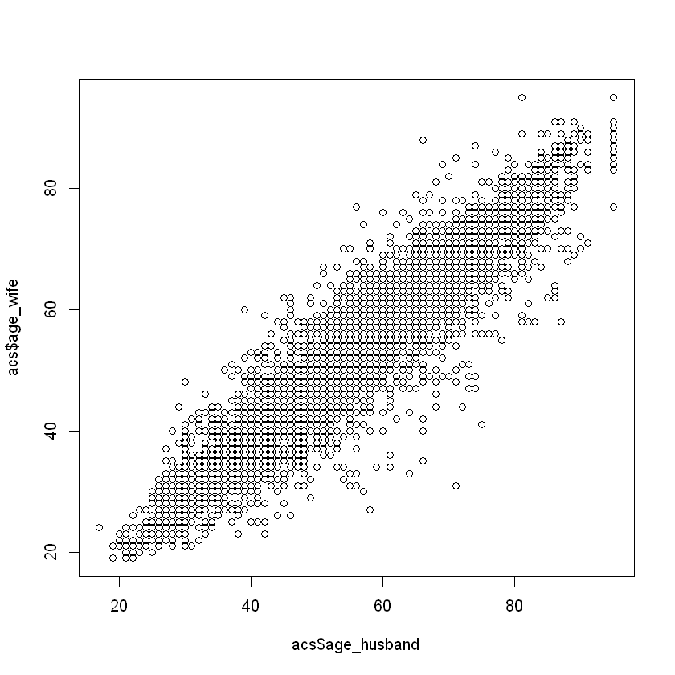

```r
# Scatter plot
plot(x = acs$age_husband , y = acs$age_wife, type = 'p')
```

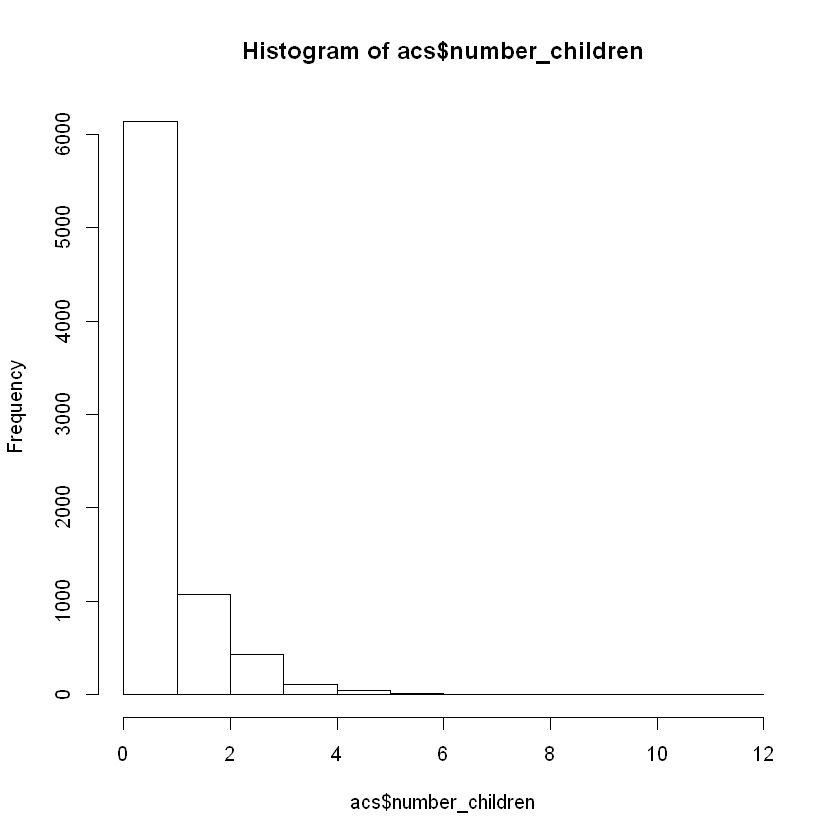

```r
# Histogram
hist(acs$number_children)
```

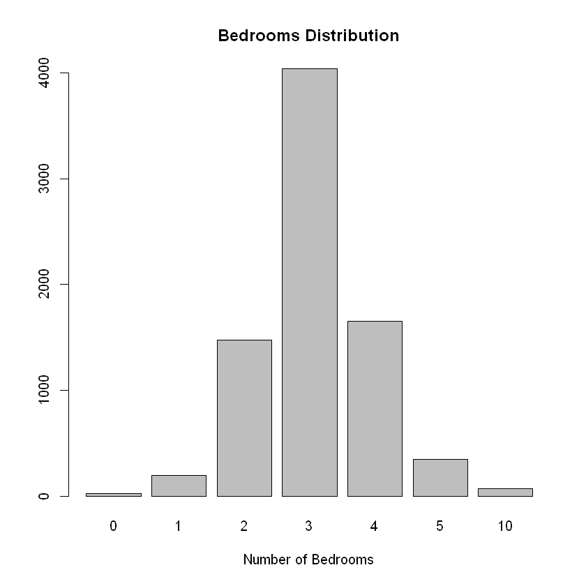

```r
# Bar Plots
counts <- table(acs$bedrooms)
barplot(counts, main="Bedrooms Distribution",  xlab="Number of Bedrooms")
```

## Export plot

```r
png(file="saving_plot2.png",width=600, height=600)
counts <- table(acs$bedrooms)
barplot(counts, main="Bedrooms Distribution",  xlab="Number of Bedrooms")
dev.off()
```

**png:** 2

# Moving average example

## Environment preparation

```r
install.packages("readxl", lib='C:/Users/Junior/Documents/R/win-library/3.6')
install.packages("tseries", lib='C:/Users/Junior/Documents/R/win-library/3.6')
install.packages("forecast", lib='C:/Users/Junior/Documents/R/win-library/3.6')
install.packages("data.table", lib='C:/Users/Junior/Documents/R/win-library/3.6')
install.packages("TTR", lib='C:/Users/Junior/Documents/R/win-library/3.6')

library(readxl)
library(forecast)
library(tseries)
library(data.table)
library(TTR)
```

```
forecast   8.14   8.15              TRUE

  Binaries will be installed
```

```r
# Load the data
data <- read_xlsx("01. Belgium.xlsx", sheet =1, col_names = TRUE)
# Data preparation
colnames(data) <- c("GEO/TIME", "TimeT", "Y", "X1", "X2", "NOCOL", "CODE", "COUNTRY", "START", "END","TOTOAL_ROWS", "TRAIN_ROWS", "TEST_ROWS")
data
```

```
* `` -> ...6
```

| GEO/TIME | TimeT | Y | X1 | X2 | NOCOL | CODE | COUNTRY | START | END | TOTOAL_ROWS | TRAIN_ROWS | TEST_ROWS |
| --- | --- | --- | --- | --- | --- | --- | --- | --- | --- | --- | --- | --- |
| 1995Q1 | 1 | 52684.8 | 3839 | 51435.45 | NA | 1 | Belgium | 1995Q1 | 2013Q2 | 74 | 64 | 10 |
| 1995Q2 | 2 | 55264.1 | 3851 | 52222.83 | NA | NA | NA | NA | NA | NA | NA | NA |
| 1995Q3 | 3 | 53314.0 | 3930 | 52848.80 | NA | NA | NA | NA | NA | NA | NA | NA |
| 1995Q4 | 4 | 56360.1 | 3872 | 53069.26 | NA | NA | NA | NA | NA | NA | NA | NA |
| 1996Q1 | 5 | 53529.7 | 3859 | 52600.77 | NA | NA | NA | NA | NA | NA | NA | NA |
| 1996Q2 | 6 | 54844.7 | 3858 | 52703.13 | NA | NA | NA | NA | NA | NA | NA | NA |
| 1996Q3 | 7 | 53087.9 | 3937 | 53289.73 | NA | NA | NA | NA | NA | NA | NA | NA |
| 1996Q4 | 8 | 55798.2 | 3879 | 54356.62 | NA | NA | NA | NA | NA | NA | NA | NA |
| 1997Q1 | 9 | 53291.0 | 3876 | 55238.49 | NA | NA | NA | NA | NA | NA | NA | NA |
| 1997Q2 | 10 | 55663.4 | 3877 | 56435.30 | NA | NA | NA | NA | NA | NA | NA | NA |
| 1997Q3 | 11 | 53929.2 | 3963 | 56226.65 | NA | NA | NA | NA | NA | NA | NA | NA |
| 1997Q4 | 12 | 57565.3 | 3923 | 57663.61 | NA | NA | NA | NA | NA | NA | NA | NA |
| 1998Q1 | 13 | 55446.5 | 3926 | 57344.72 | NA | NA | NA | NA | NA | NA | NA | NA |
| 1998Q2 | 14 | 57614.5 | 3936 | 57616.37 | NA | NA | NA | NA | NA | NA | NA | NA |
| 1998Q3 | 15 | 55954.7 | 4047 | 58710.82 | NA | NA | NA | NA | NA | NA | NA | NA |
| 1998Q4 | 16 | 59383.1 | 4003 | 59439.15 | NA | NA | NA | NA | NA | NA | NA | NA |
| 1999Q1 | 17 | 57400.0 | 3996 | 59285.61 | NA | NA | NA | NA | NA | NA | NA | NA |
| 1999Q2 | 18 | 59797.0 | 3989 | 59923.38 | NA | NA | NA | NA | NA | NA | NA | NA |
| 1999Q3 | 19 | 58467.0 | 4094 | 60135.98 | NA | NA | NA | NA | NA | NA | NA | NA |
| 1999Q4 | 20 | 63213.0 | 4053 | 59927.32 | NA | NA | NA | NA | NA | NA | NA | NA |
| 2000Q1 | 21 | 60961.0 | 4064 | 61856.40 | NA | NA | NA | NA | NA | NA | NA | NA |
| 2000Q2 | 22 | 63593.0 | 4069 | 62580.78 | NA | NA | NA | NA | NA | NA | NA | NA |
| 2000Q3 | 23 | 61480.0 | 4187 | 63340.60 | NA | NA | NA | NA | NA | NA | NA | NA |
| 2000Q4 | 24 | 66508.0 | 4136 | 63683.11 | NA | NA | NA | NA | NA | NA | NA | NA |
| 2001Q1 | 25 | 62993.0 | 4141 | 64482.30 | NA | NA | NA | NA | NA | NA | NA | NA |
| 2001Q2 | 26 | 66007.0 | 4139 | 63628.00 | NA | NA | NA | NA | NA | NA | NA | NA |
| 2001Q3 | 27 | 63107.0 | 4242 | 64167.35 | NA | NA | NA | NA | NA | NA | NA | NA |
| 2001Q4 | 28 | 67696.0 | 4160 | 61742.23 | NA | NA | NA | NA | NA | NA | NA | NA |
| 2002Q1 | 29 | 64761.0 | 4143 | 61470.58 | NA | NA | NA | NA | NA | NA | NA | NA |
| 2002Q2 | 30 | 67787.0 | 4145 | 60565.10 | NA | NA | NA | NA | NA | NA | NA | NA |
| ... | ... | ... | ... | ... | ... | ... | ... | ... | ... | ... | ... | ... |
| 2006Q1 | 45 | 76692 | 4256 | 70954.55 | NA | NA | NA | NA | NA | NA | NA | NA |
| 2006Q2 | 46 | 79983 | 4288 | 70761.64 | NA | NA | NA | NA | NA | NA | NA | NA |
| 2006Q3 | 47 | 77571 | 4393 | 71911.21 | NA | NA | NA | NA | NA | NA | NA | NA |
| 2006Q4 | 48 | 84583 | 4308 | 72226.16 | NA | NA | NA | NA | NA | NA | NA | NA |
| 2007Q1 | 49 | 81014 | 4321 | 74084.37 | NA | NA | NA | NA | NA | NA | NA | NA |
| 2007Q2 | 50 | 84646 | 4354 | 75139.46 | NA | NA | NA | NA | NA | NA | NA | NA |
| 2007Q3 | 51 | 81628 | 4467 | 76584.30 | NA | NA | NA | NA | NA | NA | NA | NA |
| 2007Q4 | 52 | 88527 | 4388 | 77989.77 | NA | NA | NA | NA | NA | NA | NA | NA |
| 2008Q1 | 53 | 84239 | 4407 | 78619.67 | NA | NA | NA | NA | NA | NA | NA | NA |
| 2008Q2 | 54 | 88294 | 4436 | 78674.79 | NA | NA | NA | NA | NA | NA | NA | NA |
| 2008Q3 | 55 | 84678 | 4550 | 76946.49 | NA | NA | NA | NA | NA | NA | NA | NA |
| 2008Q4 | 56 | 89164 | 4451 | 75478.03 | NA | NA | NA | NA | NA | NA | NA | NA |
| 2009Q1 | 57 | 82046 | 4431 | 72840.32 | NA | NA | NA | NA | NA | NA | NA | NA |
| 2009Q2 | 58 | 85445 | 4433 | 71426.97 | NA | NA | NA | NA | NA | NA | NA | NA |
| 2009Q3 | 59 | 83158 | 4520 | 69505.77 | NA | NA | NA | NA | NA | NA | NA | NA |
| 2009Q4 | 60 | 90090 | 4426 | 70072.68 | NA | NA | NA | NA | NA | NA | NA | NA |
| 2010Q1 | 61 | 84463 | 4429 | 68934.92 | NA | NA | NA | NA | NA | NA | NA | NA |
| 2010Q2 | 62 | 89928 | 4456 | 69470.34 | NA | NA | NA | NA | NA | NA | NA | NA |
| 2010Q3 | 63 | 86946 | 4567 | 70596.29 | NA | NA | NA | NA | NA | NA | NA | NA |
| 2010Q4 | 64 | 94732 | 4481 | 71434.85 | NA | NA | NA | NA | NA | NA | NA | NA |
| 2011Q1 | 65 | 89350 | 4495 | 71867.91 | NA | NA | NA | NA | NA | NA | NA | NA |
| 2011Q2 | 66 | 93658 | 4526 | 74005.64 | NA | NA | NA | NA | NA | NA | NA | NA |
| 2011Q3 | 67 | 89711 | 4627 | 73517.46 | NA | NA | NA | NA | NA | NA | NA | NA |
| 2011Q4 | 68 | 97262 | 4532 | 72828.51 | NA | NA | NA | NA | NA | NA | NA | NA |
| 2012Q1 | 69 | 91276 | 4525 | 73198.57 | NA | NA | NA | NA | NA | NA | NA | NA |
| 2012Q2 | 70 | 94959 | 4537 | 72564.73 | NA | NA | NA | NA | NA | NA | NA | NA |
| 2012Q3 | 71 | 90938 | 4626 | 72698.59 | NA | NA | NA | NA | NA | NA | NA | NA |
| 2012Q4 | 72 | 99055 | 4525 | 71926.96 | NA | NA | NA | NA | NA | NA | NA | NA |
| 2013Q1 | 73 | 92517 | 4512 | 70797.07 | NA | NA | NA | NA | NA | NA | NA | NA |
| 2013Q2 | 74 | 96534 | 4524 | 70604.16 | NA | NA | NA | NA | NA | NA | NA | NA |

```r
total_rows <- as.numeric(data[1,11])
train_rows <- as.numeric(data[1,12])
test_rows <- as.numeric(data[1,13])
workingNumber<-train_rows+1
data <- data[ ,-1]
data <- data[ , -c(5:12)]
data
```

| TimeT | Y | X1 | X2 |
| --- | --- | --- | --- |
| 1 | 52684.8 | 3839 | 51435.45 |
| 2 | 55264.1 | 3851 | 52222.83 |
| 3 | 53314.0 | 3930 | 52848.80 |
| 4 | 56360.1 | 3872 | 53069.26 |
| 5 | 53529.7 | 3859 | 52600.77 |
| 6 | 54844.7 | 3858 | 52703.13 |
| 7 | 53087.9 | 3937 | 53289.73 |
| 8 | 55798.2 | 3879 | 54356.62 |
| 9 | 53291.0 | 3876 | 55238.49 |
| 10 | 55663.4 | 3877 | 56435.30 |
| 11 | 53929.2 | 3963 | 56226.65 |
| 12 | 57565.3 | 3923 | 57663.61 |
| 13 | 55446.5 | 3926 | 57344.72 |
| 14 | 57614.5 | 3936 | 57616.37 |
| 15 | 55954.7 | 4047 | 58710.82 |
| 16 | 59383.1 | 4003 | 59439.15 |
| 17 | 57400.0 | 3996 | 59285.61 |
| 18 | 59797.0 | 3989 | 59923.38 |
| 19 | 58467.0 | 4094 | 60135.98 |
| 20 | 63213.0 | 4053 | 59927.32 |
| 21 | 60961.0 | 4064 | 61856.40 |
| 22 | 63593.0 | 4069 | 62580.78 |
| 23 | 61480.0 | 4187 | 63340.60 |
| 24 | 66508.0 | 4136 | 63683.11 |
| 25 | 62993.0 | 4141 | 64482.30 |
| 26 | 66007.0 | 4139 | 63628.00 |
| 27 | 63107.0 | 4242 | 64167.35 |
| 28 | 67696.0 | 4160 | 61742.23 |
| 29 | 64761.0 | 4143 | 61470.58 |
| 30 | 67787.0 | 4145 | 60565.10 |
| ... | ... | ... | ... |
| 45 | 76692 | 4256 | 70954.55 |
| 46 | 79983 | 4288 | 70761.64 |
| 47 | 77571 | 4393 | 71911.21 |
| 48 | 84583 | 4308 | 72226.16 |
| 49 | 81014 | 4321 | 74084.37 |
| 50 | 84646 | 4354 | 75139.46 |
| 51 | 81628 | 4467 | 76584.30 |
| 52 | 88527 | 4388 | 77989.77 |
| 53 | 84239 | 4407 | 78619.67 |
| 54 | 88294 | 4436 | 78674.79 |
| 55 | 84678 | 4550 | 76946.49 |
| 56 | 89164 | 4451 | 75478.03 |
| 57 | 82046 | 4431 | 72840.32 |
| 58 | 85445 | 4433 | 71426.97 |
| 59 | 83158 | 4520 | 69505.77 |
| 60 | 90090 | 4426 | 70072.68 |
| 61 | 84463 | 4429 | 68934.92 |
| 62 | 89928 | 4456 | 69470.34 |
| 63 | 86946 | 4567 | 70596.29 |
| 64 | 94732 | 4481 | 71434.85 |
| 65 | 89350 | 4495 | 71867.91 |
| 66 | 93658 | 4526 | 74005.64 |
| 67 | 89711 | 4627 | 73517.46 |
| 68 | 97262 | 4532 | 72828.51 |
| 69 | 91276 | 4525 | 73198.57 |
| 70 | 94959 | 4537 | 72564.73 |
| 71 | 90938 | 4626 | 72698.59 |
| 72 | 99055 | 4525 | 71926.96 |
| 73 | 92517 | 4512 | 70797.07 |
| 74 | 96534 | 4524 | 70604.16 |

## Modelling & Forecasting

```r
i=1
current_row=1
working_Y <-rep(0, total_rows)
working_Y <- as.data.frame(working_Y)
working_SMA <- as.data.frame(shift(SMA(data[,2],n=3),1))
for (i in 1:total_rows) {
  if (current_row <= train_rows ) {
    working_Y[i,1] <- data[i,2]
  }else{ working_Y[i,1] <- working_SMA[i,1]}

  working_SMA <- as.data.frame(shift(SMA(working_Y[,1],n=3),1))
  current_row = current_row + 1
}

forecast11 <- as.data.frame(shift(SMA(working_Y, 3),1))
forecast11
```

| shift(SMA(working_Y, 3), 1) |
| --- |
| NA |
| NA |
| NA |
| 53754.30 |
| 54979.40 |
| 54401.27 |
| 54911.50 |
| 53820.77 |
| 54576.93 |
| 54059.03 |
| 54917.53 |
| 54294.53 |
| 55719.30 |
| 55647.00 |
| 56875.43 |
| 56338.57 |
| 57650.77 |
| 57579.27 |
| 58860.03 |
| 58554.67 |
| 60492.33 |
| 60880.33 |
| 62589.00 |
| 62011.33 |
| 63860.33 |
| 63660.33 |
| 65169.33 |
| 64035.67 |
| 65603.33 |
| 65188.00 |
| ... |
| 76891.67 |
| 77060.00 |
| 79146.00 |
| 78082.00 |
| 80712.33 |
| 81056.00 |
| 83414.33 |
| 82429.33 |
| 84933.67 |
| 84798.00 |
| 87020.00 |
| 85737.00 |
| 87378.67 |
| 85296.00 |
| 85551.67 |
| 83549.67 |
| 86231.00 |
| 85903.67 |
| 88160.33 |
| 87112.33 |
| 90535.33 |
| 90737.78 |
| 92001.70 |
| 91091.60 |
| 91277.03 |
| 91456.78 |
| 91275.14 |
| 91336.32 |
| 91356.08 |
| 91322.51 |

## Analysis

```r
# Calculate mean relative error
abs11yf <- abs(forecast11-data[,2])
abs11y <- abs(data[,2])
R11 <<- sum(abs11yf[4:train_rows,1])/sum(abs11y[4:train_rows,1])
S11 <<- sum(abs11yf[(train_rows+1):total_rows,1])/sum(abs11y[(train_rows+1):total_rows,1])
```

```
 Simple moving average (3 periods) : F(t)=(Y(t-1)+Y(t-2)+Y(t-3))/3:
 R = 3.47 %;   S = 3.26
```

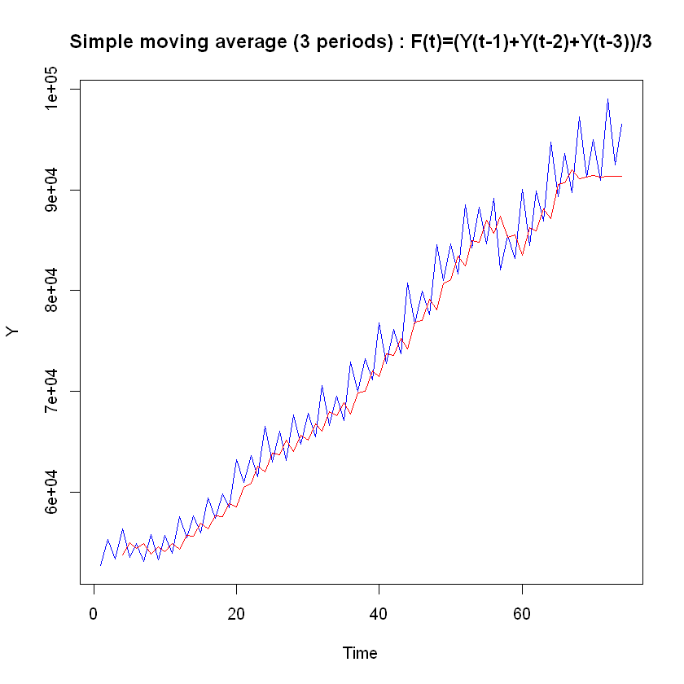

```r
plot.ts(data[,2], type="l", col = "blue", main = "Simple moving average (3 periods) : F(t)=(Y(t-1)+Y(t-2)+Y(t-3))/3" )
lines(forecast11, type="l", col = "red")

cat("\n","\n","Simple moving average (3 periods) : F(t)=(Y(t-1)+Y(t-2)+Y(t-3))/3:  ","\n", "R =", round(R11*100, digits = 2), "%;", "  S =", round(S11*100, digits = 2))
```